# Исследование и очистка данных клиентской базы ОТП-банка

Б.Романов, Д.Пак, М.Вотякова

# Очистка

Загрузка библиотек

```r
library(tidyverse)
library(readxl)
library(stringr)
```

Загрузка данных

О данных

```r
names (otp)
```

```
##  [1] "agreement_rk"               "target"
##  [3] "age"                        "socstatus_work_fl"
##  [5] "socstatus_pens_fl"          "gender"
##  [7] "child_total"                "dependants"
##  [9] "education"                  "marital_status"
## [11] "gen_industry"               "gen_title"
## [13] "org_tp_state"               "org_tp_fcapital"
## [15] "job_dir"                    "family_income"
## [17] "personal_income"            "reg_address_province"
## [19] "fact_address_province"      "postal_address_province"
## [21] "tp_province"                "region_nm"
## [23] "reg_fact_fl"                "fact_post_fl"
## [25] "reg_post_fl"                "reg_fact_post_fl"
## [27] "reg_fact_post_tp_fl"        "fl_presence_fl"
## [29] "own_auto"                   "auto_rus_fl"
## [31] "hs_presence_fl"             "cot_presence_fl"
## [33] "gar_presence_fl"            "land_presence_fl"
## [35] "credit"                     "term"
## [37] "fst_payment"                "dl_document_fl"
## [39] "gpf_document_fl"            "fact_living_term"
## [41] "work_time"                  "fact_phone_fl"
## [43] "reg_phone_fl"               "gen_phone_fl"
## [45] "loan_num_total"             "loan_num_closed"
## [47] "loan_num_paym"              "loan_dlq_num"
## [49] "loan_max_dlq"               "loan_avg_dlq_amt"
## [51] "loan_max_dlq_amt"           "previous_card_num_utilized"
```

```r
# summary(otp_num)
# names(otp_num)
```

Создание нового набора данных

```r
otp_num <- select(otp, -reg_address_province, -fact_address_province,-region_nm, -agreement_rk, - postal_address_province, -job_dir, -gen_industry, -org_tp_state, -org_tp_fcapital, -education, - socstatus_work_fl, -socstatus_pens_fl, -marital_status, -gen_title, -family_income, -tp_province)
```

Фильтрация пропущенных значений

```r
otp_na <-  filter(otp_num, is.na(work_time)| is.na(previous_card_num_utilized))
```

Фильтруем категориальные переменные

```r
otp_cat <- select(otp, reg_address_province, fact_address_province,region_nm, agreement_rk,  postal_address_province, job_dir, gen_industry, org_tp_state, org_tp_fcapital, education,  socstatus_work_fl, socstatus_pens_fl, marital_status, gen_title, family_income, tp_province)
```

Поскольку данные переменные являются категориальными, допустимо заменить пропущенные значения аргументом “Неизвестно”

Наконец, производим замены.

```r
otp_clean <- mutate(otp, previous_card_num_utilized = if_else(is.na(otp$previous_card_num_utilized), 0, previous_card_num_utilized), work_time = if_else(is.na(otp$work_time), mean(!is.na(otp$work_time)), otp$work_time), reg_address_province = if_else(is.na(otp$reg_address_province), "Неизвестно", otp$reg_address_province), fact_address_province = if_else(is.na(otp$fact_address_province), "Неизвестно", otp$fact_address_province), region_nm = if_else(is.na(otp$region_nm), "Неизвестно", otp$region_nm), postal_address_province = if_else(is.na(otp$postal_address_province), "Неизвестно", otp$postal_address_province), job_dir = if_else(is.na(otp$job_dir), "Неизвестно", otp$job_dir), gen_industry = if_else(is.na(otp$gen_industry), "Неизвестно", otp$gen_industry), org_tp_state = if_else(is.na(otp$org_tp_state), "Неизвестно", otp$org_tp_state), education = if_else(is.na(otp$education), "Неизвестно", otp$education), socstatus_work_fl = if_else(is.na(otp$socstatus_work_fl), "Неизвестно", otp$socstatus_work_fl), socstatus_pens_fl = if_else(is.na(otp$socstatus_pens_fl), "Неизвестно", otp$socstatus_pens_fl), marital_status = if_else(is.na(otp$marital_status), "Неизвестно", otp$marital_status), gen_title = if_else(is.na(otp$gen_title), "Неизвестно", otp$gen_title), family_income = if_else(is.na(otp$family_income), "Неизвестно", otp$family_income), tp_province = if_else(is.na(otp$tp_province), "Неизвестно", otp$tp_province))
```

# Изучение всех количественных столбцов таблицы

На основе анализа распределений нами была выбрана следующая стратегия обработки аномальных значений: винзоризация. Поскольку этот метод в отличие, например, от фильтрации не будет приводить к большой потере данных.

Для того чтобы понять,какие количественные переменные нужно винзоризировать, построим ящичные диаграммы для каждой переменной.

## Возраст клиента (ящичная диаграмма)

```r
# Сводка
summary(otp_clean$age)
```

```
##    Min. 1st Qu.  Median    Mean 3rd Qu.    Max.
##   21.00   30.00   39.00   40.41   50.00   67.00
```

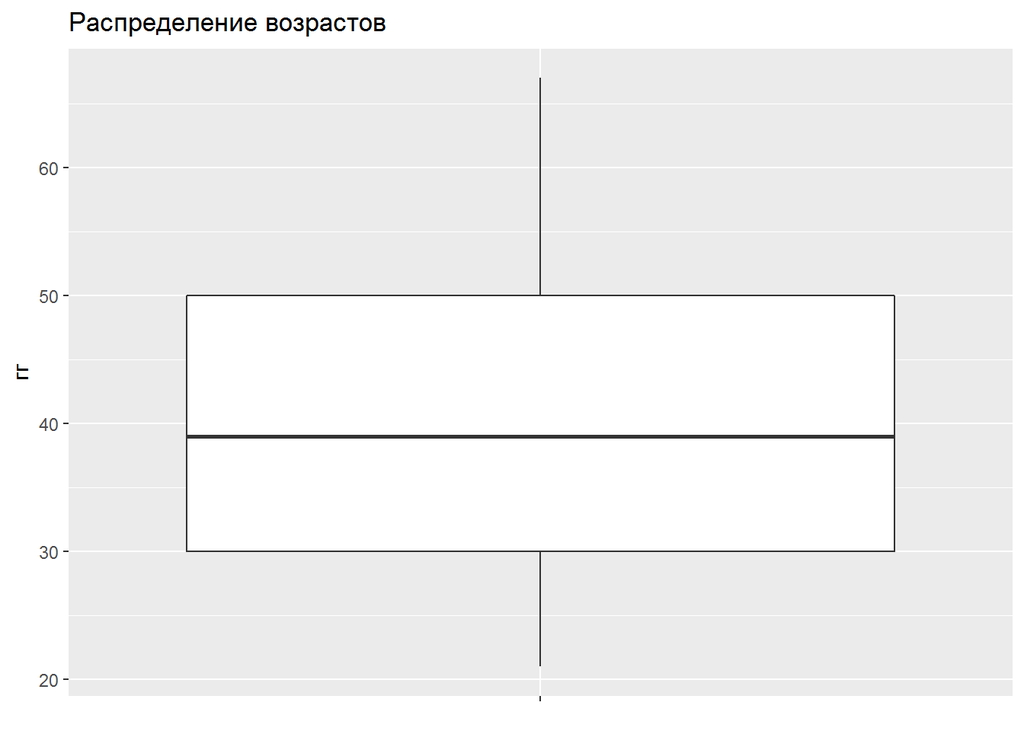

```r
# Ящичная диаграмма
qplot(x = "", y = age, data = otp_clean,
      geom = 'boxplot',
      main = 'Распределение возрастов',
      ylab = 'гг',
      xlab = NULL)
```

Как мы видим, выбросов переменной “возраст клиента” нет, поэтому можно не винзоризировать значения для данной переменной.

Перейдем к следующей переменной.

## Личный доход клиента (ящичная диаграмма)

```r
# Сводка
summary(otp_clean$personal_income)
```

```
##    Min. 1st Qu.  Median    Mean 3rd Qu.    Max.
##      24    8000   12000   13854   17000  250000
```

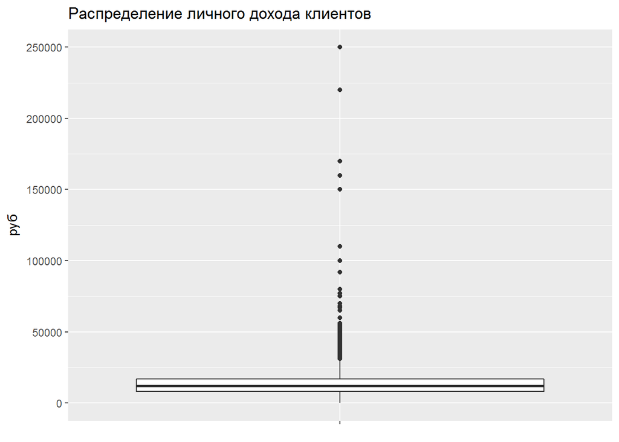

```r
# Ящичная диаграмма
qplot(x = "", y = personal_income, data = otp_clean,
      geom = 'boxplot',
      main = 'Распределение личного дохода клиентов',
      ylab = 'руб',
      xlab = NULL)
```

Выбросов достаточно много, поэтому будем винзоризировать переменную ‘личный доход клиента (в рублях)’.

## Сумма последнего кредита клиента (ящичная диагамма)

```r
# Сводка
summary(otp_clean$credit)
```

```
##    Min. 1st Qu.  Median    Mean 3rd Qu.    Max.
##    2000    6500   11550   14668   19170  119700
```

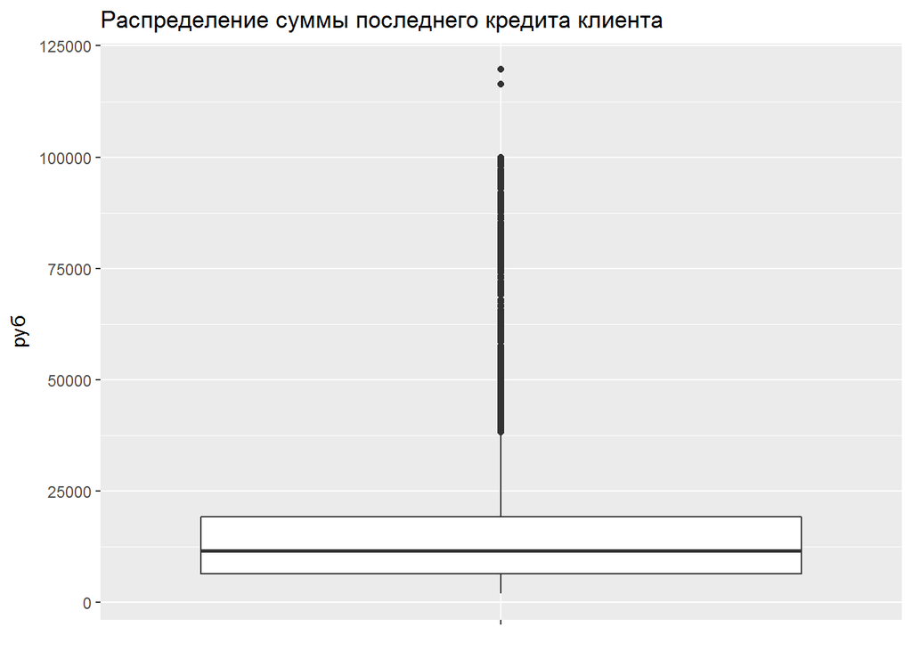

```r
# Ящичная диаграмма
qplot(x = "", y = credit, data = otp_clean,
      geom = 'boxplot',
      main = 'Распределение суммы последнего кредита клиента',
      ylab = 'руб',
      xlab = NULL)
```

Выбросов достаточно много, поэтому будем винзоризировать переменную ‘сумма последнего кредита клиента (в рублях)’.

## Первоначальный взнос (ящичная диаграмма)

```r
# Сводка
summary(otp_clean$fst_payment)
```

```
##    Min. 1st Qu.  Median    Mean 3rd Qu.    Max.
##       0    1000    2000    3399    4000  140000
```

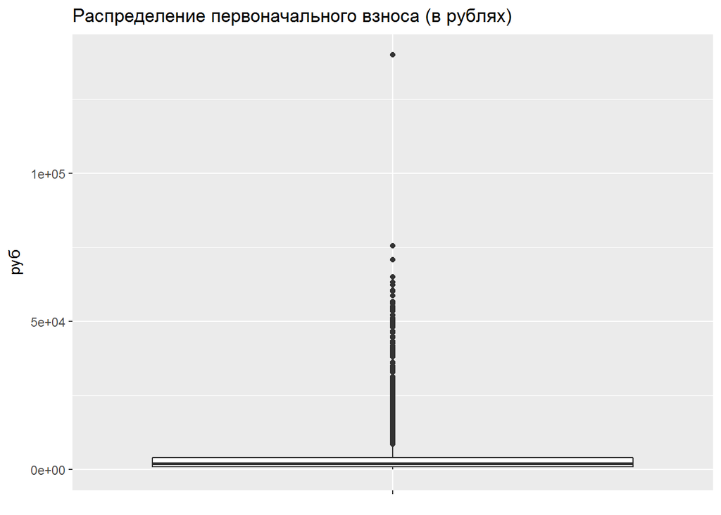

```r
# Ящичная диаграмма
qplot(x = "", y = fst_payment, data = otp_clean,
      geom = 'boxplot',
      main = 'Распределение первоначального взноса (в рублях)',
      ylab = 'руб',
      xlab = NULL)
```

Выбросов достаточно много, поэтому будем винзоризировать переменную ‘первоначальный взнос (в рублях)’.

## Средняя сумма просрочки (ящичная диаграмма)

```r
# Сводка
summary(otp_clean$loan_avg_dlq_amt)
```

```
##    Min. 1st Qu.  Median    Mean 3rd Qu.    Max.
##     0.0     0.0     0.0   239.5     0.0 28012.2
```

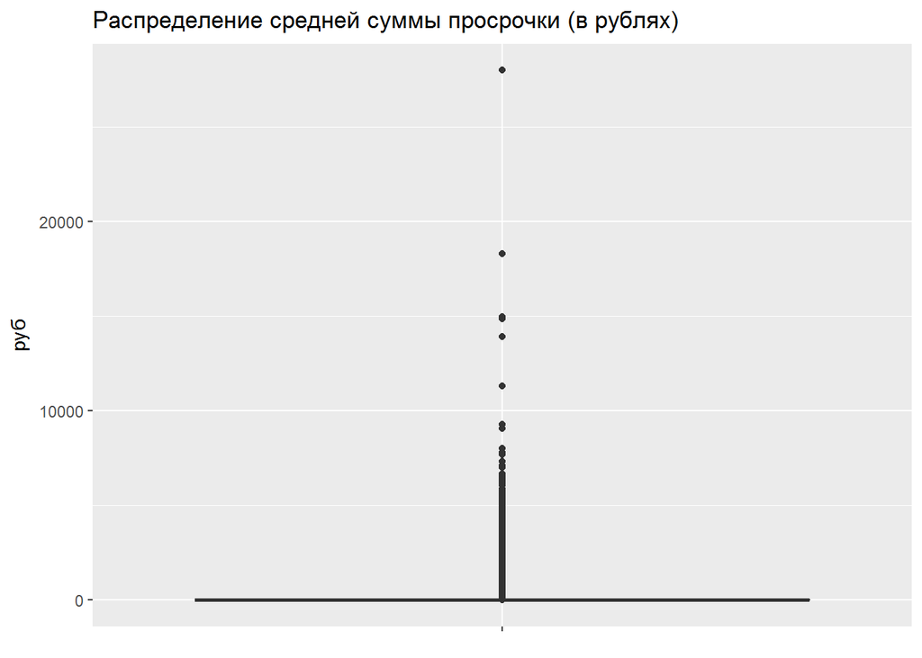

```r
# Ящичная диаграмма
qplot(x = "", y = loan_avg_dlq_amt, data = otp_clean,
      geom = 'boxplot',
      main = 'Распределение средней суммы просрочки (в рублях)',
      ylab = 'руб',
      xlab = NULL)
```

В данном случае ящичная диаграмма дает ложное представление о распределении: подавляющее большинство клиентов не имеют задолженности, поэтому задолженности, отличные от нуля воспринимаются как выброс.